# PART A: Recurrent Neural Network & Classification

# 1. Data Processing

# a) Import the following libraries

```python
# ! pip install tensorflow keras
```

```python
import tensorflow as tf
print("TensorFlow version:", tf.__version__)

# If you're using TensorFlow 2.x, Keras is included as part of TensorFlow and can be imported directly from TensorFlow.
```

```
TensorFlow version: 2.16.1
```

```python
import sys
import os
import json
import pandas
import numpy
import optparse

from keras.callbacks import TensorBoard
from keras.models import Sequential, load_model
from keras.layers import LSTM, Dense, Dropout
from keras.layers import Embedding
from keras.preprocessing import sequence
from tensorflow.keras.preprocessing.text import Tokenizer
from collections import OrderedDict
```

# b) We will read the code in slightly differently than before:

```python
dataframe = pandas.read_csv("dev-access.csv", engine='python', quotechar='|', header=None)
dataframe.head(3)
```

|  | 0 | 1 |
| --- | --- | --- |
| 0 | {"timestamp":1502738402847,"method":"post","qu... | 0 |
| 1 | {"timestamp":1502738402849,"method":"post","qu... | 0 |
| 2 | {"timestamp":1502738402852,"method":"post","qu... | 0 |

# c) We then need to convert to a numpy.ndarray type:

```python
dataset = dataframe.values
```

```python
type(dataset)
```

```
numpy.ndarray
```

```python
dataset
```

```
array([['{"timestamp":1502738402847,"method":"post","query":{},"path":"/login","statusCode":401,"source":{"remoteAddress":"88.141.113.237","referer":"http://localhost:8002/enter"},"route":"/login","headers":{"host":"localhost:8002","accept-language":"en-us","accept-encoding":"gzip, deflate","connect…
        0],
       ['{"timestamp":1502738402849,"method":"post","query":{},"path":"/login","statusCode":401,"source":{"remoteAddress":"88.141.113.237"},"route":"/login","headers":{"host":"localhost:8002","connection":"keep-alive","cache-control":"no-cache","accept":"*/*","accept-encoding":"gzip, deflate, br","a…
        0],
       ['{"timestamp":1502738402852,"method":"post","query":{},"path":"/login","statusCode":401,"source":{"remoteAddress":"205.49.83.118"},"route":"/login","headers":{"host":"localhost:8002","connection":"keep-alive","cache-control":"no-cache","accept":"*/*","accept-encoding":"gzip, deflate, br","ac…
        0],
       ...,
       ['{"timestamp":1502738800390,"method":"post","query":{},"path":"/checkout","statusCode":400,"source":{"remoteAddress":"233.150.201.166"},"route":"/checkout","headers":{"host":"localhost:8002","connection":"keep-alive","cache-control":"no-cache","accept":"*/*","accept-encoding":"gzip, deflate,…
        1],
       ['{"timestamp":1502738803362,"method":"post","query":{},"path":"/checkout","statusCode":400,"source":{"remoteAddress":"182.239.131.78","referer":"http://localhost:8002/enter"},"route":"/checkout","headers":{"host":"localhost:8002","connection":"keep-alive","accept":"*/*","cache-control":"no-c…
        1],
       ['{"timestamp":1502738810082,"method":"post","query":{},"path":"/checkout","statusCode":400,"source":{"remoteAddress":"182.239.131.78"},"route":"/checkout","headers":{"host":"localhost:8002","connection":"keep-alive","cache-control":"no-cache","accept":"*/*","accept-encoding":"gzip, deflate, …
        1]], dtype=object)
```

numpy.ndarray is a fundamental data structure in the NumPy library, representing a multidimensional array of elements of the same data type. It allows efficient storage and manipulation of large datasets, enabling mathematical operations such as addition, subtraction, multiplication, and more on entire arrays at once.

```python
len(dataset)
```

```
26773
```

# d) Check the shape of the data set - it should be (26773, 2). Spend some time looking at the data.

```python
dataset.shape
```

```
(26773, 2)
```

# e) Store all rows and the 0th index as the feature data:

```python
X = dataset[:,0]
```

```python
X
```

```
array(['{"timestamp":1502738402847,"method":"post","query":{},"path":"/login","statusCode":401,"source":{"remoteAddress":"88.141.113.237","referer":"http://localhost:8002/enter"},"route":"/login","headers":{"host":"localhost:8002","accept-language":"en-us","accept-encoding":"gzip, deflate","connecti…
       '{"timestamp":1502738402849,"method":"post","query":{},"path":"/login","statusCode":401,"source":{"remoteAddress":"88.141.113.237"},"route":"/login","headers":{"host":"localhost:8002","connection":"keep-alive","cache-control":"no-cache","accept":"*/*","accept-encoding":"gzip, deflate, br","ac…
       '{"timestamp":1502738402852,"method":"post","query":{},"path":"/login","statusCode":401,"source":{"remoteAddress":"205.49.83.118"},"route":"/login","headers":{"host":"localhost:8002","connection":"keep-alive","cache-control":"no-cache","accept":"*/*","accept-encoding":"gzip, deflate, br","acc…
       ...,
       '{"timestamp":1502738800390,"method":"post","query":{},"path":"/checkout","statusCode":400,"source":{"remoteAddress":"233.150.201.166"},"route":"/checkout","headers":{"host":"localhost:8002","connection":"keep-alive","cache-control":"no-cache","accept":"*/*","accept-encoding":"gzip, deflate, …
       '{"timestamp":1502738803362,"method":"post","query":{},"path":"/checkout","statusCode":400,"source":{"remoteAddress":"182.239.131.78","referer":"http://localhost:8002/enter"},"route":"/checkout","headers":{"host":"localhost:8002","connection":"keep-alive","accept":"*/*","cache-control":"no-ca…
       '{"timestamp":1502738810082,"method":"post","query":{},"path":"/checkout","statusCode":400,"source":{"remoteAddress":"182.239.131.78"},"route":"/checkout","headers":{"host":"localhost:8002","connection":"keep-alive","cache-control":"no-cache","accept":"*/*","accept-encoding":"gzip, deflate, b…
      dtype=object)
```

```python
X.shape
```

```
(26773,)
```

# f) Store all rows and index 1 as the target variable:

```python
Y = dataset[:,1]
```

```python
Y
```

```
array([0, 0, 0, ..., 1, 1, 1], dtype=object)
```

# g) In the next step, we will clean up the predictors. This includes removing features that are not valuable, such as timestamp and source.

```python
for index, item in enumerate(X):
    # Quick hack to space out json elements
    reqJson = json.loads(item, object_pairs_hook=OrderedDict)
    del reqJson['timestamp']
    del reqJson['headers']
    del reqJson['source']
    del reqJson['route']
    del reqJson['responsePayload']
    X[index] = json.dumps(reqJson, separators=(',', ':'))
```

```python
X
```

```
array(['{"method":"post","query":{},"path":"/login","statusCode":401,"requestPayload":{"username":"Carl2","password":"bo"}}',
       '{"method":"post","query":{},"path":"/login","statusCode":401,"requestPayload":{"username":"pafzah","password":"worldburn432"}}',
       '{"method":"post","query":{},"path":"/login","statusCode":401,"requestPayload":{"username":"Panos1","password":"najrijkom"}}',
       ...,
       '{"method":"post","query":{},"path":"/checkout","statusCode":400,"requestPayload":{"creditCard":"<script src=\\"http://attacker/malicious\\u2011script.js\\"></script>"}}',
       '{"method":"post","query":{},"path":"/checkout","statusCode":400,"requestPayload":{"creditCard":"<meta http-equiv=\\"refresh\\">"}}',
       '{"method":"post","query":{},"path":"/checkout","statusCode":400,"requestPayload":{"creditCard":"<meta http-equiv=\\"refresh\\">"}}'],
      dtype=object)
```

# h) We next will tokenize our data, which just means vectorizing our text. Given the data we will tokenize every character (thus char_level = True)

```python
tokenizer = Tokenizer(filters='\t\n', char_level=True)
tokenizer.fit_on_texts(X)

# we will need this later
num_words = len(tokenizer.word_index)+1
X = tokenizer.texts_to_sequences(X)
```

```python
tokenizer
```

```
<keras.src.legacy.preprocessing.text.Tokenizer at 0x2a09b372ed0>
```

```python
X[0]
```

```
[18,
 1,
 20,
 2,
 3,
 14,
 7,
 11,
 1,
 4,
 1,
 13,
 7,
 6,
 3,
 1,
 10,
 1,
 16,
 8,
 2,
 9,
 15,
 1,
 4,
 18,
 19,
 10,
 1,
 13,
 5,
 3,
 14,
 1,
 4,
 1,
 25,
 12,
 7,
 26,
```

[output cut: 60 more lines]

```
 5,
 6,
 6,
 32,
 7,
 9,
 11,
 1,
 4,
 1,
 40,
 7,
 1,
 19,
 19]
```

```python
len(X[0])
```

```
115
```

```python
# X[1]
```

```python
num_words
```

```
63
```

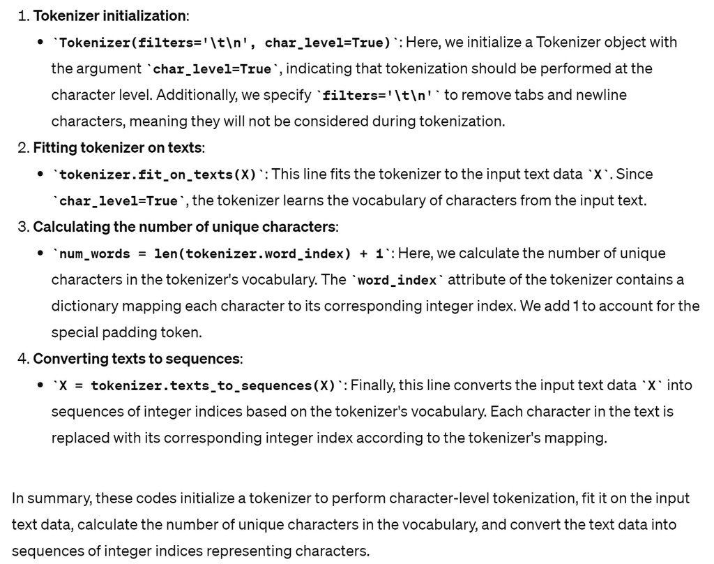

# i) Need to pad our data as each observation has a different length

```python
max_log_length = 1024
X_processed = sequence.pad_sequences(X, maxlen=max_log_length)
```

```python
X_processed[0]
```

```
array([ 0,  0,  0, ...,  1, 19, 19])
```

```python
len(X_processed[0])
```

```
1024
```

```python
type(X_processed)
```

```
numpy.ndarray
```

```python
Y
```

```
array([0, 0, 0, ..., 1, 1, 1], dtype=object)
```

# Y array contains dtype object, which suggests that it might contain non-numeric or mixed data types. To resolve this issue, you should ensure that your target labels are properly encoded as numeric values. For binary classification tasks like yours, you can use LabelEncoder from Scikit-learn to encode the labels as 0s and 1s.

```python
from sklearn.preprocessing import LabelEncoder

# Initialize LabelEncoder
label_encoder = LabelEncoder()

# Fit and transform the labels
Y_encoded = label_encoder.fit_transform(Y)

# Check the unique classes after encoding
print("Unique classes:", label_encoder.classes_)

# Now Y_train_encoded should contain numeric labels (0s and 1s)
print("Encoded Y:", Y_encoded)
```

```
Unique classes: [0 1]
Encoded Y: [0 0 0 ... 1 1 1]
```

# j) Create your train set to be 75% of the data and your test set to be 25%

```python
from sklearn.model_selection import train_test_split

# Split the data into training and testing sets
X_train, X_test, Y_train, Y_test = train_test_split(X_processed, Y_encoded, test_size=0.25, random_state=42)

# Check the shapes of the train and test sets
print("Shape of X_train:", X_train.shape)
print("Shape of X_test:", X_test.shape)
print("Shape of Y_train:", Y_train.shape)
print("Shape of Y_test:", Y_test.shape)
```

```
Shape of X_train: (20079, 1024)
Shape of X_test: (6694, 1024)
Shape of Y_train: (20079,)
Shape of Y_test: (6694,)
```

# 2. Model 1 - RNN: The first model will be a pretty minimal RNN with only an embedding layer, simple RNN and Dense layer. The next model we will add a few more layers.

```python
from keras.models import Sequential
from keras.layers import Embedding, SimpleRNN, Dense
from keras.optimizers import Adam
```

# a) Start by creating an instance of a Sequential model: https://keras.io/getting-started/sequential-model-guide/Links to an external site.

```python
model = Sequential()
```

# b) From there, add an Embedding layer: https://keras.io/layers/embeddings/ Links to an external site.

Params:

- input_dim = num_words (the variable we created above) 63
- output_dim = 32
- input_length = max_log_length (we also created this above)
- Keep all other variables as the defaults (shown below)

```python
model.add(Embedding(input_dim=num_words, output_dim=32, input_length=max_log_length))
```

input_dim represents the number of unique characters in your vocabulary.

output_dim represents the dimensionality of the embedding space. The output_dim parameter in the Embedding layer specifies the dimensionality of the dense embedding vector for each word/character in the input sequence.

input_length represents the length of input sequences.

An "embedding" refers to a mapping of words or tokens from a high-dimensional space (such as a vocabulary) to a lower-dimensional continuous vector space. Each word or token is represented by a dense vector in this lower-dimensional space, where similar words are expected to have similar vector representations.

In the embedding layer, I have input_dim = num_words = 63 and nput_length = max_log_length = 1024. how can the output_dim = 32, which is smaller than 63 and 1024?

The output_dim parameter in the Embedding layer specifies the dimensionality of the embedding space, which is not directly related to the input dimensions (input_dim and input_length).

In the context of the Embedding layer, the **output_dim parameter determines the size of the vector representation for each word/character in the vocabulary**. It does not need to match the input dimensions (input_dim and input_length).

Having a smaller output dimensionality (output_dim = 32) compared to the input dimensions (input_dim = 63 and input_length = 1024) means that each word/character in the vocabulary will be represented by a vector of size 32 in the embedding space. This compression of dimensionality helps in reducing the computational complexity of the model and can also aid in generalization by capturing essential semantic information in a lower-dimensional space.

# c) Add a SimpleRNN layer: https://keras.io/layers/recurrent/Links to an external site.

Params:

- units = 32
- activation = 'relu'

```python
model.add(SimpleRNN(units=32, activation='relu'))
```

The choice of units=32 in the SimpleRNN layer indicates that there will be 32 units in the hidden state of the RNN.

This parameter determines the size of the internal representation maintained by the RNN layer during processing.

**Is the "32" in "SimpleRNN (32 units, relu activation)" decided by any of the parameters in the embedding layer below?**

From there, add an Embedding layer -

Params:

- input_dim = num_words = 63
- output_dim = 32
- input_length = max_log_length = 1024

No, the "32" in "SimpleRNN (32 units, relu activation)" is not directly decided by any of the parameters in the embedding layer.

In the embedding layer, the "output_dim" parameter specifies the dimensionality of the embedding space, which in this case is set to 32. This parameter determines the size of the vector representation for each word/character in the vocabulary.

On the other hand, in the SimpleRNN layer, the "units" parameter specifies the dimensionality of the output space, which refers to the number of units (neurons) in the RNN layer. This parameter determines the complexity and capacity of the RNN layer to learn patterns and relationships in the data.

While you can choose to have the number of units in the SimpleRNN layer be the same as the output dimension of the embedding layer for compatibility, it is not a strict requirement. The choice of the number of units in the SimpleRNN layer depends on factors such as the complexity of the problem, the size of the dataset, and empirical experimentation.

Each word/character in the vocabulary will be represented by a vector of size 32

"Each unit handles information from the entire input sequence, but they collectively contribute to the model's understanding of the sequence."

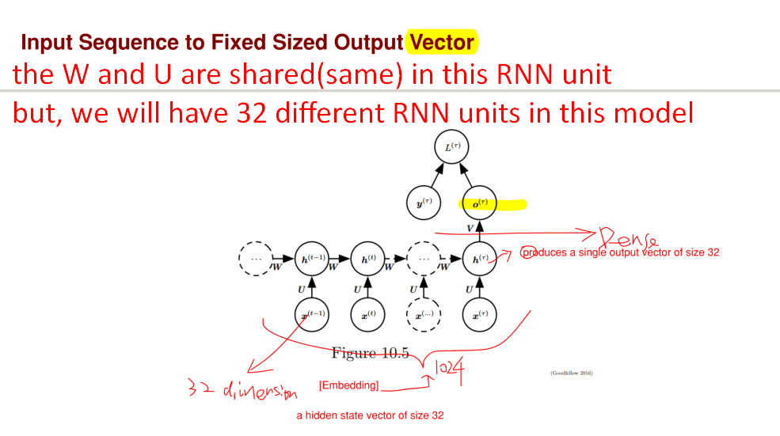

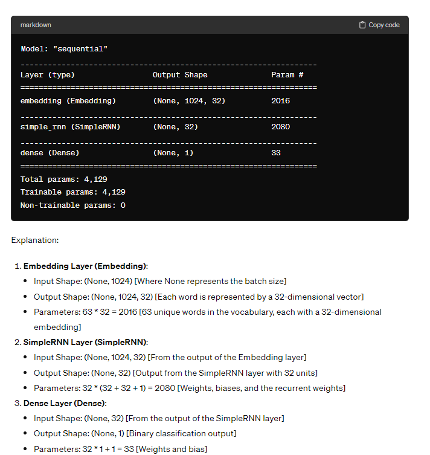

[figure not shown]

[figure not shown]

# "For each unit, there are 32 weights corresponding to the connections between the input at each timestep and the current state of the unit."

[figure not shown]

# d) Finally, we will add a Dense layer: https://keras.io/layers/core/#denseLinks to an external site.

Params:

- units = 1 (this will be our output)
- activation --> you can choose to use either relu or sigmoid

```python
model.add(Dense(units=1, activation='sigmoid'))
```

Dense layer is a fully connected neural network layer. It is added after the SimpleRNN layer and serves as the output layer of the model.

The Dense layer consists of multiple neurons, or units, each connected to every neuron in the preceding layer. In this specific case, the Dense layer has units=1, meaning it has a single neuron. The activation function used for this neuron is 'sigmoid', indicating that the output of this neuron will be a value between 0 and 1, representing the probability of the input belonging to a certain class (in binary classification tasks).

Therefore, the Dense layer aggregates the information learned by the preceding layers and produces the final output of the model. In the context of the provided instructions, it serves as the classification layer, making predictions based on the features extracted by the embedding and SimpleRNN layers.

# e) Compile model using the .compile() method: https://keras.io/models/model/Links to an external site.

Params:

- loss = binary_crossentropy
- optimizer = adam
- metrics = accuracy

```python
# Build the model
model.build((None, max_log_length))
```

```python
model.compile(loss='binary_crossentropy', optimizer='adam', metrics=['accuracy'])
```

# f) Print the model summary

```python
print(model.summary())
```

```
Model: "sequential"
```

```
┏━━━━━━━━━━━━━━━━━━━━━━━━━━━━━━━━━━━━━━┳━━━━━━━━━━━━━━━━━━━━━━━━━━━━━┳━━━━━━━━━━━━━━━━━┓
┃ Layer (type)                         ┃ Output Shape                ┃         Param # ┃
┡━━━━━━━━━━━━━━━━━━━━━━━━━━━━━━━━━━━━━━╇━━━━━━━━━━━━━━━━━━━━━━━━━━━━━╇━━━━━━━━━━━━━━━━━┩
│ embedding (Embedding)                │ (None, 1024, 32)            │           2,016 │
├──────────────────────────────────────┼─────────────────────────────┼─────────────────┤
│ simple_rnn (SimpleRNN)               │ (None, 32)                  │           2,080 │
├──────────────────────────────────────┼─────────────────────────────┼─────────────────┤
│ dense (Dense)                        │ (None, 1)                   │              33 │
└──────────────────────────────────────┴─────────────────────────────┴─────────────────┘
```

```
 Total params: 4,129 (16.13 KB)
```

```
 Trainable params: 4,129 (16.13 KB)
```

```
 Non-trainable params: 0 (0.00 B)
```

```
None
```

```python
model
```

```
<Sequential name=sequential, built=False>
```

# g) Use the .fit() method to fit the model on the train data. Use a validation split of 0.25, epochs=3 and batch size = 128.

```python
history = model.fit(X_train, Y_train, validation_split=0.25, epochs=3, batch_size=128)
```

```
118/118 ━━━━━━━━━━━━━━━━━━━━ 17s 132ms/step - accuracy: 0.6372 - loss: 0.6363 - val_accuracy: 0.8851 - val_loss: 0.3395
118/118 ━━━━━━━━━━━━━━━━━━━━ 15s 129ms/step - accuracy: 0.8942 - loss: 0.3352 - val_accuracy: 0.9528 - val_loss: 0.1840
118/118 ━━━━━━━━━━━━━━━━━━━━ 15s 127ms/step - accuracy: 0.9327 - loss: 0.2262 - val_accuracy: 0.9635 - val_loss: 0.1617
```

# h) Use the .evaluate() method to get the loss value & the accuracy value on the test data. Use a batch size of 128 again.

```python
test_loss, test_accuracy = model.evaluate(X_test, Y_test, batch_size=128)
print("Test Loss:", test_loss)
print("Test Accuracy:", test_accuracy)
```

```
53/53 ━━━━━━━━━━━━━━━━━━━━ 1s 27ms/step - accuracy: 0.9556 - loss: 0.1764
Test Loss: 0.17083998024463654
Test Accuracy: 0.9581714868545532
```

# 3. Model 2 - LSTM + Dropout Layers:

# Now we will add a few new layers to our RNN and incorporate the more powerful LSTM. You will be creating a new model here, so make sure to call it something different than the model from Part 2.

# a) This RNN needs to have the following layers (add in this order):

- Embedding Layer (use same params as before)
- LSTM Layer (units = 64, recurrent_dropout = 0.5)
- Dropout Layer - use a value of 0.5
- Dense Layer - (use same params as before)

```python
# Create a new Sequential model
model_lstm = Sequential()
```

```python
# Add Embedding layer
model_lstm.add(Embedding(input_dim=num_words, output_dim=32, input_length=max_log_length))
```

```python
# Add LSTM layer
model_lstm.add(LSTM(units=64, recurrent_dropout=0.5))
```

```python
# Add Dropout layer
model_lstm.add(Dropout(0.5))
```

```python
# Add Dense layer
model_lstm.add(Dense(units=1, activation='sigmoid'))
```

LSTM: This specifies the type of recurrent layer we're adding, which is a Long Short-Term Memory layer.

units=64: This parameter specifies the dimensionality of the output space, i.e., the number of units or neurons in the LSTM layer. In this case, we're using 64 units. When you set units=64 in the LSTM layer, it means that the **LSTM layer will have 64 individual LSTM units or memory cells**. Each of these units processes input data sequentially and maintains its own internal state, allowing the network to capture temporal dependencies in the data. So, indeed, the LSTM layer will contain 64 LSTM units.

units=64 parameter in the LSTM layer determines the number of LSTM units in the layer, and each unit produces a 64-dimensional hidden state vector at each time step.

# b) Compile model using the .compile() method:

Params:

- loss = binary_crossentropy
- optimizer = adam
- metrics = accuracy

```python
model_lstm.compile(loss='binary_crossentropy', optimizer='adam', metrics=['accuracy'])
```

# c) Print the model summary

```python
max_log_length
```

```
1024
```

```python
# Build the model
model_lstm.build((None, max_log_length))
```

```python
print(model_lstm.summary())
```

```
Model: "sequential_1"
```

```
┏━━━━━━━━━━━━━━━━━━━━━━━━━━━━━━━━━━━━━━┳━━━━━━━━━━━━━━━━━━━━━━━━━━━━━┳━━━━━━━━━━━━━━━━━┓
┃ Layer (type)                         ┃ Output Shape                ┃         Param # ┃
┡━━━━━━━━━━━━━━━━━━━━━━━━━━━━━━━━━━━━━━╇━━━━━━━━━━━━━━━━━━━━━━━━━━━━━╇━━━━━━━━━━━━━━━━━┩
│ embedding_1 (Embedding)              │ (None, 1024, 32)            │           2,016 │
├──────────────────────────────────────┼─────────────────────────────┼─────────────────┤
│ lstm (LSTM)                          │ (None, 64)                  │          24,832 │
├──────────────────────────────────────┼─────────────────────────────┼─────────────────┤
│ dropout (Dropout)                    │ (None, 64)                  │               0 │
├──────────────────────────────────────┼─────────────────────────────┼─────────────────┤
│ dense_1 (Dense)                      │ (None, 1)                   │              65 │
└──────────────────────────────────────┴─────────────────────────────┴─────────────────┘
```

```
 Total params: 26,913 (105.13 KB)
```

```
 Trainable params: 26,913 (105.13 KB)
```

```
 Non-trainable params: 0 (0.00 B)
```

```
None
```

# d) Use the .fit() method to fit the model on the train data. Use a validation split of 0.25, epochs=3 and batch size = 128.

```python
history_lstm = model_lstm.fit(X_train, Y_train, validation_split=0.25, epochs=3, batch_size=128)
```

```
118/118 ━━━━━━━━━━━━━━━━━━━━ 82s 683ms/step - accuracy: 0.6303 - loss: 0.6366 - val_accuracy: 0.8586 - val_loss: 0.4361
118/118 ━━━━━━━━━━━━━━━━━━━━ 89s 757ms/step - accuracy: 0.8516 - loss: 0.4081 - val_accuracy: 0.9378 - val_loss: 0.2128
118/118 ━━━━━━━━━━━━━━━━━━━━ 93s 787ms/step - accuracy: 0.9146 - loss: 0.2867 - val_accuracy: 0.9552 - val_loss: 0.1680
```

# e) Use the .evaluate() method to get the loss value & the accuracy value on the test data. Use a batch size of 128 again.

```python
test_loss_lstm, test_accuracy_lstm = model_lstm.evaluate(X_test, Y_test, batch_size=128)
print("Test Loss:", test_loss_lstm)
print("Test Accuracy:", test_accuracy_lstm)
```

```
53/53 ━━━━━━━━━━━━━━━━━━━━ 7s 137ms/step - accuracy: 0.9503 - loss: 0.1807
Test Loss: 0.17888306081295013
Test Accuracy: 0.9515984654426575
```

# 4. Recurrent Neural Net Model 3: Build Your Own

```python
import numpy as np
from keras.models import Sequential
from keras.layers import LSTM, Dense, Dropout


# Reshape the input data for LSTM
X_train = np.reshape(X_train, (X_train.shape[0], X_train.shape[1], 1))

# Create own RNN model
model_custom_rnn = Sequential()

# Add layers
model_custom_rnn.add(LSTM(units=64, return_sequences=True, input_shape=(X_train.shape[1], 1)))
model_custom_rnn.add(Dropout(0.2))
model_custom_rnn.add(LSTM(units=64))
model_custom_rnn.add(Dense(units=32, activation='relu'))
model_custom_rnn.add(Dense(units=1, activation='sigmoid'))

# Compile the model
model_custom_rnn.compile(loss='binary_crossentropy', optimizer='adam', metrics=['accuracy'])

# Print model summary
print(model_custom_rnn.summary())

# Fit the model
history = model_custom_rnn.fit(X_train, Y_train, validation_split=0.25, epochs=3, batch_size=128)

# Assuming you have preprocessed X_test and Y_test

# Reshape the input data for LSTM
X_test = np.reshape(X_test, (X_test.shape[0], X_test.shape[1], 1))

# Evaluate the model
test_loss, test_accuracy = model_custom_rnn.evaluate(X_test, Y_test, batch_size=128)
print('Test Loss:', test_loss)
print('Test Accuracy:', test_accuracy)
```

```
Model: "sequential_4"
```

```
┏━━━━━━━━━━━━━━━━━━━━━━━━━━━━━━━━━━━━━━┳━━━━━━━━━━━━━━━━━━━━━━━━━━━━━┳━━━━━━━━━━━━━━━━━┓
┃ Layer (type)                         ┃ Output Shape                ┃         Param # ┃
┡━━━━━━━━━━━━━━━━━━━━━━━━━━━━━━━━━━━━━━╇━━━━━━━━━━━━━━━━━━━━━━━━━━━━━╇━━━━━━━━━━━━━━━━━┩
│ lstm_3 (LSTM)                        │ (None, 1024, 64)            │          16,896 │
├──────────────────────────────────────┼─────────────────────────────┼─────────────────┤
│ dropout_2 (Dropout)                  │ (None, 1024, 64)            │               0 │
├──────────────────────────────────────┼─────────────────────────────┼─────────────────┤
│ lstm_4 (LSTM)                        │ (None, 64)                  │          33,024 │
├──────────────────────────────────────┼─────────────────────────────┼─────────────────┤
│ dense_4 (Dense)                      │ (None, 32)                  │           2,080 │
├──────────────────────────────────────┼─────────────────────────────┼─────────────────┤
│ dense_5 (Dense)                      │ (None, 1)                   │              33 │
└──────────────────────────────────────┴─────────────────────────────┴─────────────────┘
```

```
 Total params: 52,033 (203.25 KB)
```

```
 Trainable params: 52,033 (203.25 KB)
```

```
 Non-trainable params: 0 (0.00 B)
```

```
None
118/118 ━━━━━━━━━━━━━━━━━━━━ 402s 3s/step - accuracy: 0.6175 - loss: 0.6326 - val_accuracy: 0.7522 - val_loss: 0.4948
118/118 ━━━━━━━━━━━━━━━━━━━━ 424s 4s/step - accuracy: 0.7666 - loss: 0.4680 - val_accuracy: 0.7618 - val_loss: 0.4547
118/118 ━━━━━━━━━━━━━━━━━━━━ 407s 3s/step - accuracy: 0.7884 - loss: 0.4289 - val_accuracy: 0.8020 - val_loss: 0.3952
53/53 ━━━━━━━━━━━━━━━━━━━━ 19s 349ms/step - accuracy: 0.8138 - loss: 0.3863
Test Loss: 0.3901096284389496
Test Accuracy: 0.811174213886261
```

```python
X_train
```

[output not shown]

```python
Y_train
```

```
array([1, 0, 1, ..., 1, 1, 0])
```

# Explain the difference between the relu activation function and the sigmoid activation function.

ReLU is often preferred in hidden layers due to its simplicity, faster convergence, and ability to mitigate the vanishing gradient problem. Sigmoid is commonly used in the output layer for binary classification tasks, where the output needs to be interpreted as probabilities. However, both activation functions have their advantages and disadvantages, and the choice depends on the specific requirements of the task and the architecture of the neural network.

# Describe what one epoch actually is (epoch was a parameter used in the .fit() method).

In the context of training a neural network, an epoch refers to one complete pass through the entire training dataset during the training phase.

Here's how it typically works:

Forward Pass: During an epoch, each training sample in the dataset is passed through the network in sequence. The input data is fed forward through the network layers, and predictions are made for each sample.

Backward Pass (Backpropagation): After the predictions are made, the error between the predicted outputs and the actual targets (labels) is calculated using a loss function. This error is then used to update the network's weights and biases through the process of backpropagation, which involves computing gradients and applying optimization algorithms such as gradient descent.

Update Parameters: The optimization algorithm adjusts the parameters (weights and biases) of the network in the direction that reduces the loss, aiming to improve the model's performance on the training data.

Repeat for Each Epoch: This process is repeated for each epoch until the specified number of epochs is reached or until convergence criteria are met. **Each epoch allows the model to learn from the entire dataset multiple times, potentially improving its ability to generalize to unseen data**.

In summary, one epoch represents a single iteration over the entire training dataset, where the model learns from each sample, updates its parameters based on the computed error, and iteratively improves its performance over multiple epochs. The number of epochs is a hyperparameter that determines how many times the model will cycle through the dataset during training. **More epochs can lead to better convergence and improved model performance, but too many epochs may lead to overfitting or increased computational cost**.

# Explain how dropout works (you can look at the keras code and/or documentation) for (a) training, and (b) test data sets.

Dropout is a regularization technique used in neural networks to prevent overfitting. It works by randomly setting a fraction of input units (or neurons) to zero during each training iteration, effectively "dropping out" these units from the network. This helps prevent complex co-adaptations between neurons, forcing the network to learn more robust and generalized features.

Here's how dropout works during training and testing:

Training Phase:

During training, dropout is applied to the input units (or neurons) of the network with a specified dropout rate (typically between 0.2 and 0.5). For each training example or mini-batch, the **dropout layer randomly sets a fraction of the input units to zero with probability equal to the dropout rate**. This means that the activations of these units are ignored during forward and backward propagation, and their weights are not updated during parameter updates.

The dropout layer ensures that **each training example or mini-batch sees a different network architecture** because different sets of neurons are dropped out each time. This helps **prevent the network from relying too much on any specific set of features**, encouraging it to learn more robust and generalized representations of the data.

Test Phase:

During testing (or inference), dropout is not applied. Instead, the **learned weights of the network are scaled by the dropout rate to compensate for the dropped-out units during training**. This is done to ensure that the expected output of the network remains the same during testing as it was during training.

In Keras, dropout can be implemented using the Dropout layer. During training, the Dropout layer randomly sets a fraction of input units to zero, while during testing, it scales the output by the dropout rate to ensure consistent behavior.

Here's an example of how dropout is implemented in Keras:

from keras.models import Sequential

from keras.layers import Dense, Dropout

model = Sequential()

model.add(Dense(64, activation='relu'))

model.add(Dropout(0.5)) # Dropout rate of 0.5

model.add(Dense(10, activation='softmax'))

In this example, a Dropout layer with a dropout rate of 0.5 is added after the first Dense layer. During training, the **Dropout layer will randomly drop out 50% of the input units, while during testing, it will scale the output by 0.5 to ensure consistent behavior**.

# Explain why problems such as this homework assignment are better modeled with RNNs than CNNs. What type of problem will CNNs outperform RNNs on?

Problems that involve sequential or time-dependent data are often better modeled with Recurrent Neural Networks (RNNs) than Convolutional Neural Networks (CNNs). This is because RNNs are designed to handle sequential data by maintaining internal state or memory, allowing them to capture dependencies and patterns across time steps. Here's why problems like the homework assignment might be better suited for RNNs:

Temporal Dependencies: In many tasks, such as time series forecasting or natural language processing, the **current output depends not only on the current input but also on the sequence of inputs that came before it. RNNs are well-suited to capture such temporal dependencies due to their recurrent connections**, which allow information to persist across time steps.

Variable-Length Sequences: RNNs can handle input sequences of variable length, **making them flexible for tasks where the length of the input sequence may vary**. This is especially important in tasks like text processing, where sentences or documents can have different lengths.

Sequential Processing: RNNs process input sequences sequentially, one element at a time, which aligns well with the nature of sequential data. This sequential processing allows RNNs to capture **intricate patterns and relationships within the data**.

While RNNs are powerful for sequential data, CNNs are better suited for tasks that involve spatial or hierarchical patterns, such as image classification or object detection. CNNs excel at **capturing local patterns in data through their shared weight scheme and hierarchical feature extraction**. Here's when CNNs might outperform RNNs:

Spatial Patterns: CNNs are highly effective at capturing spatial patterns in data, such as shapes, textures, and edges. They achieve this by applying convolutional filters across the input data, allowing them to extract local features efficiently.

Translation-Invariant Features: CNNs are invariant to translations in the input data, **making them ideal for tasks where the location of features is not important**. This property is particularly useful in image processing tasks like object recognition.

Fixed-Length Inputs: **CNNs require fixed-size input tensors**, which makes them suitable for tasks where the input data has a fixed spatial dimensionality. This makes CNNs well-suited for tasks like image classification, where images are typically of fixed size.

In summary, RNNs are preferred for tasks involving sequential or time-dependent data, while CNNs are more suitable for tasks involving spatial or hierarchical patterns. Each type of neural network has its strengths and weaknesses, and the choice between RNNs and CNNs depends on the nature of the data and the specific requirements of the task.

# Explain what RNN problem is solved using LSTM and briefly describe how.

Recurrent Neural Networks (RNNs) are powerful for modeling sequential data, but they face challenges in capturing long-term dependencies due to the vanishing gradient problem. Long Short-Term Memory (LSTM) networks were designed to address this issue by incorporating a memory mechanism that allows them to capture long-range dependencies in sequential data.

The main problem solved by LSTMs within RNNs is the ability to **effectively learn and remember information over long sequences**. **Traditional RNNs have difficulty retaining information over many time steps due to the vanishing gradient problem**, where gradients become extremely small during backpropagation, leading to a loss of information over time. This limitation hinders the ability of RNNs to capture long-term dependencies in sequences.

LSTMs overcome this problem by introducing **a memory cell that maintains a constant error flow through time**. The key components of an LSTM cell include:

Forget Gate: This gate determines which information to discard from the cell state. It takes input from the current input and the previous hidden state and outputs a forget vector, which **determines how much of each component of the cell state to forget**.

Input Gate: This gate determines which new information to store in the cell state. It takes input from the current input and the previous hidden state and outputs an input vector, which **determines how much of each component of the cell state to update**.

Cell State Update: The input gate's output is used to update the cell state with new information, **preserving the information that is deemed relevant by the forget and input gates**.

Output Gate: This gate determines the output of the LSTM cell based on the updated cell state. It takes input from the current input and the previous hidden state and outputs the current hidden state, which is also the output of the LSTM cell.

By carefully controlling the flow of information through these gates, LSTMs can selectively remember or forget information over long sequences, enabling them to capture long-term dependencies in sequential data. This makes LSTMs particularly effective for tasks such as **language modeling, speech recognition, machine translation, and time series forecasting, where capturing long-range dependencies is crucial for accurate predictions**.

# PART B: Time Series with LSTMs

# Import, clean and plot the input data

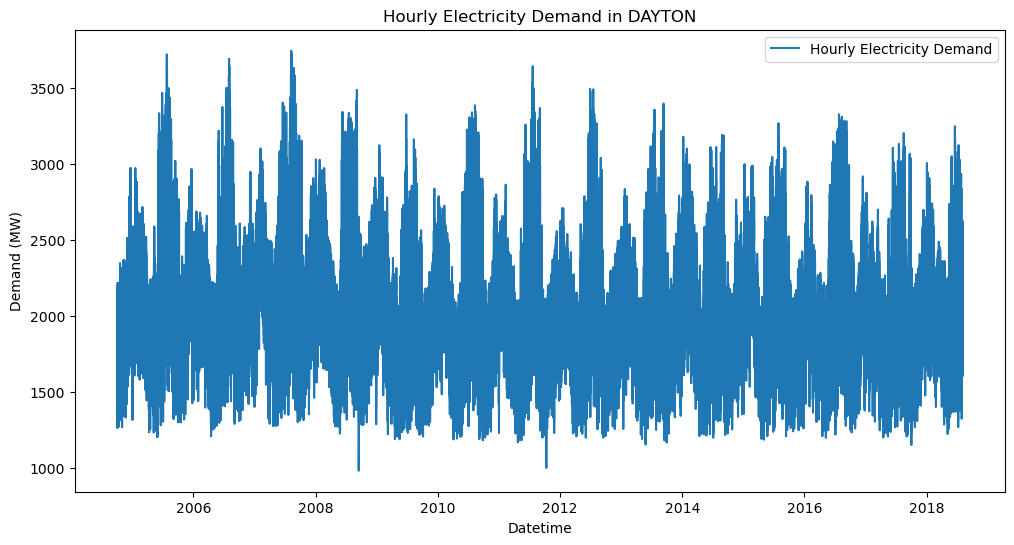

```python
import pandas as pd
import matplotlib.pyplot as plt

# Load the data
data = pd.read_csv('DAYTON_hourly.csv')

# Convert 'Datetime' to datetime type if it's not already
data['Datetime'] = pd.to_datetime(data['Datetime'], errors='coerce')  # Coerce errors will set invalid parsing as NaT

# Sort the data by datetime
data.sort_values('Datetime', inplace=True)

# Drop any rows that have missing values
data.dropna(inplace=True)

# Ensure there are no duplicate datetime entries
data = data.drop_duplicates(subset='Datetime')

# Plotting the data
plt.figure(figsize=(12, 6))
plt.plot(data['Datetime'], data['DAYTON_MW'], label='Hourly Electricity Demand')
plt.title('Hourly Electricity Demand in DAYTON')
plt.xlabel('Datetime')
plt.ylabel('Demand (MW)')
plt.legend()
plt.show()
```

```python
data
```

|  | Datetime | DAYTON_MW |
| --- | --- | --- |
| 2183 | 2004-10-01 01:00:00 | 1621.0 |
| 2184 | 2004-10-01 02:00:00 | 1536.0 |
| 2185 | 2004-10-01 03:00:00 | 1500.0 |
| 2186 | 2004-10-01 04:00:00 | 1434.0 |
| 2187 | 2004-10-01 05:00:00 | 1489.0 |
| ... | ... | ... |
| 116159 | 2018-08-02 20:00:00 | 2554.0 |
| 116160 | 2018-08-02 21:00:00 | 2481.0 |
| 116161 | 2018-08-02 22:00:00 | 2405.0 |
| 116162 | 2018-08-02 23:00:00 | 2250.0 |
| 116163 | 2018-08-03 00:00:00 | 2042.0 |

121271 rows × 2 columns

# Train test split (use provided helper function helper.py Download helper.py, as we can’t use sklearn’s for time series data)

```python
import pandas as pd
import numpy as np
from typing import Tuple


def create_data_for_NN(
    data: pd.DataFrame, Y_var: str, lag: int, test_ratio: float
) -> Tuple[np.array, np.array, np.array, np.array]:
    """Function to return lagged time series data after train-test split

    Args:
        data (pd.DataFrame): Raw time series data frame
        Y_var (str): String with the name of y variable
        lag (int): number of lagged records to consider
        test_ratio (float): ratio of data to consider for test set

    Returns:
        Tuple[np.array, np.array, np.array, np.array]: Lagged and split numpy arrays
    """
    y = data[Y_var].tolist()

    X, Y = [], []

    if len(y) - lag <= 0:
        X.append(y)
    else:
        for i in range(len(y) - lag):
            Y.append(y[i + lag])
            X.append(y[i : (i + lag)])

    X, Y = np.array(X), np.array(Y)

    # Reshaping the X array to an LSTM input shape
    X = np.reshape(X, (X.shape[0], X.shape[1], 1))

    # Creating training and test sets
    X_train = X
    X_test = []

    Y_train = Y
    Y_test = []

    if test_ratio > 0:
        index = round(len(X) * test_ratio)
        X_train = X[: (len(X) - index)]
        X_test = X[-index:]

        Y_train = Y[: (len(X) - index)]
        Y_test = Y[-index:]

    return X_train, X_test, Y_train, Y_test


lag = 3
test_ratio = 0.15

data = pd.read_csv("DAYTON_hourly.csv")
data.Datetime = pd.to_datetime(data.Datetime)
data.sort_values(by="Datetime", inplace=True)

X_train, X_test, Y_train, Y_test = create_data_for_NN(
    data, data.columns[-1], lag, test_ratio
)
```

```python
X_train, X_test, Y_train, Y_test
```

```
(array([[[1621.],
         [1536.],
         [1500.]],

        [[1536.],
         [1500.],
         [1434.]],

        [[1500.],
         [1434.],
         [1489.]],

        ...,

        [[2548.],
         [2440.],
         [2371.]],

        [[2440.],
         [2371.],
         [2226.]],

        [[2371.],
         [2226.],
         [2000.]]]),
 array([[[2226.],
         [2000.],
         [1827.]],

        [[2000.],
         [1827.],
         [1696.]],

        [[1827.],
         [1696.],
         [1624.]],

        ...,

        [[2600.],
         [2554.],
         [2481.]],

        [[2554.],
         [2481.],
         [2405.]],

        [[2481.],
         [2405.],
         [2250.]]]),
 array([1434., 1489., 1620., ..., 2226., 2000., 1827.]),
 array([1696., 1624., 1580., ..., 2405., 2250., 2042.]))
```

# These datasets are now in the form expected by LSTM models, with input features shaped as sequences of past values and the target variable containing the values to predict.

# Fit a single layer LSTM with lag = 3 hours

```
1611/1611 ━━━━━━━━━━━━━━━━━━━━ 3s 1ms/step - loss: 624401.3125 - val_loss: 15229.6846
1611/1611 ━━━━━━━━━━━━━━━━━━━━ 2s 1ms/step - loss: 13631.3672 - val_loss: 5399.8135
1611/1611 ━━━━━━━━━━━━━━━━━━━━ 2s 1ms/step - loss: 5117.9258 - val_loss: 3029.7388
1611/1611 ━━━━━━━━━━━━━━━━━━━━ 2s 2ms/step - loss: 3650.5481 - val_loss: 2586.7004
1611/1611 ━━━━━━━━━━━━━━━━━━━━ 3s 2ms/step - loss: 3136.5386 - val_loss: 2262.1501
1611/1611 ━━━━━━━━━━━━━━━━━━━━ 3s 2ms/step - loss: 2672.6326 - val_loss: 2229.5286
1611/1611 ━━━━━━━━━━━━━━━━━━━━ 3s 2ms/step - loss: 2527.2339 - val_loss: 2122.4783
1611/1611 ━━━━━━━━━━━━━━━━━━━━ 2s 2ms/step - loss: 2480.7012 - val_loss: 2123.6731
1611/1611 ━━━━━━━━━━━━━━━━━━━━ 3s 2ms/step - loss: 2465.3740 - val_loss: 2203.1704
1611/1611 ━━━━━━━━━━━━━━━━━━━━ 2s 1ms/step - loss: 2850.1389 - val_loss: 2135.9324
569/569 ━━━━━━━━━━━━━━━━━━━━ 1s 1ms/step
RMSE: 46.216137355262326
```

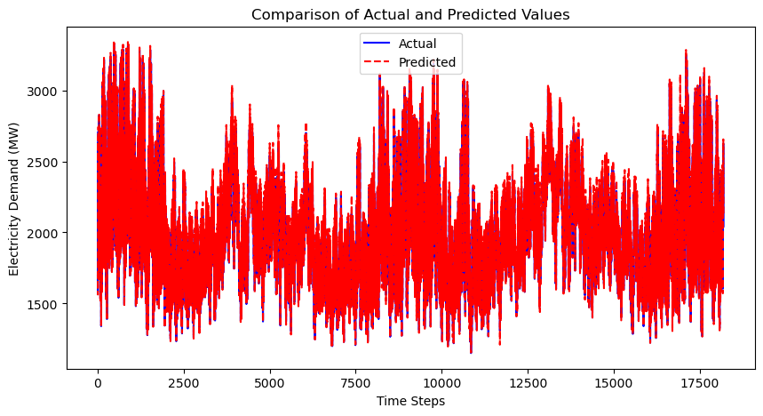

```python
import numpy as np
from tensorflow.keras.models import Sequential
from tensorflow.keras.layers import LSTM, Dense
from sklearn.metrics import mean_squared_error
import matplotlib.pyplot as plt

# Define the LSTM model
def train_single_layer_lstm(X_train, Y_train, X_test, Y_test, epochs=10, batch_size=64):
    model = Sequential([
        LSTM(50, input_shape=(X_train.shape[1], X_train.shape[2]), activation='relu'),  # 50 units, input shape (3, 1)
        Dense(1)  # Output layer with one neuron
    ])
    model.compile(optimizer='adam', loss='mean_squared_error')

    # Train the model
    history = model.fit(X_train, Y_train, epochs=epochs, batch_size=batch_size,
                        validation_data=(X_test, Y_test), verbose=1)
    return model, history

# Function to evaluate the model and plot results
def evaluate_and_plot_model(model, X_test, Y_test):
    Y_pred = model.predict(X_test)
    rmse = np.sqrt(mean_squared_error(Y_test, Y_pred.flatten()))
    print(f"RMSE: {rmse}")

    # Plotting actual vs predicted values
    plt.figure(figsize=(10, 5))
    plt.plot(Y_test, label='Actual', color='blue')
    plt.plot(Y_pred, label='Predicted', color='red', linestyle='--')
    plt.title('Comparison of Actual and Predicted Values')
    plt.xlabel('Time Steps')
    plt.ylabel('Electricity Demand (MW)')
    plt.legend()
    plt.show()
    return rmse



# Training the model
model_3h, history_3h = train_single_layer_lstm(X_train, Y_train, X_test, Y_test)

# Evaluating and plotting the model performance
rmse_3h = evaluate_and_plot_model(model_3h, X_test, Y_test)
```

```python
X_train.shape
```

```
(103081, 3, 1)
```

Steps Explained:

Define and Compile the LSTM Model: This model uses a single LSTM layer with 50 units and is designed to take an input shape that matches your data (3 hours lag, each with one feature). It's followed by a dense layer with a single unit for output, suitable for regression tasks like forecasting electricity demand.

Train the Model: The model is trained using the provided training data (X_train and Y_train), with validation on X_test and Y_test to monitor the model's performance on unseen data . Evaluate and Plot: After training, the model's predictions on the test set are compared against the actual values. The Root Mean Squared Error (RMSE) is calculated to quantify the model's predictive accuracy. Results are plotted to visually assess how well the predicted values match the actual data.

LSTM(50, input_shape=(X_train.shape[1], X_train.shape[2]), activation='relu')

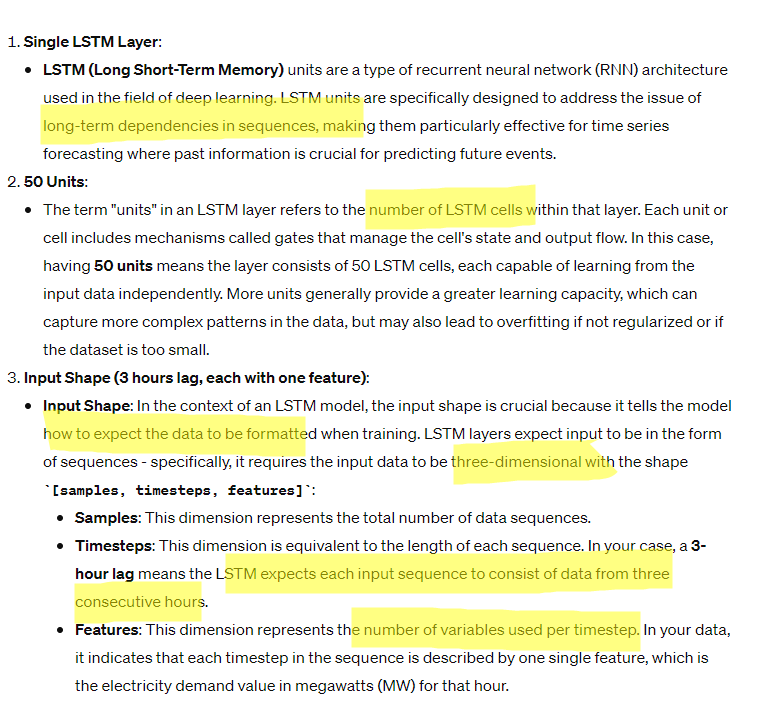

Using a single LSTM layer with 50 units designed to take input of the shape (3, 1) means that you're configuring the LSTM to process input data where each sequence consists of 3 timesteps (hours in your case), and each timestep has one feature (electricity demand). The 50 LSTM cells in the layer can learn from the patterns in these sequences to forecast future electricity demand, making use of the information from the past 3 hours to make predictions. This setup is optimized for learning the dependencies that might affect electricity usage based on the immediate three hours of data provided.

# Fit a single layer LSTM with lag = 24 hours

```python
# lag = 24
```

```python
import pandas as pd
import numpy as np
from typing import Tuple


def create_data_for_NN(
    data: pd.DataFrame, Y_var: str, lag: int, test_ratio: float
) -> Tuple[np.array, np.array, np.array, np.array]:
    """Function to return lagged time series data after train-test split

    Args:
        data (pd.DataFrame): Raw time series data frame
        Y_var (str): String with the name of y variable
        lag (int): number of lagged records to consider
        test_ratio (float): ratio of data to consider for test set

    Returns:
        Tuple[np.array, np.array, np.array, np.array]: Lagged and split numpy arrays
    """
    y = data[Y_var].tolist()

    X, Y = [], []

    if len(y) - lag <= 0:
        X.append(y)
    else:
        for i in range(len(y) - lag):
            Y.append(y[i + lag])
            X.append(y[i : (i + lag)])

    X, Y = np.array(X), np.array(Y)

    # Reshaping the X array to an LSTM input shape
    X = np.reshape(X, (X.shape[0], X.shape[1], 1))

    # Creating training and test sets
    X_train = X
    X_test = []

    Y_train = Y
    Y_test = []

    if test_ratio > 0:
        index = round(len(X) * test_ratio)
        X_train = X[: (len(X) - index)]
        X_test = X[-index:]

        Y_train = Y[: (len(X) - index)]
        Y_test = Y[-index:]

    return X_train, X_test, Y_train, Y_test


lag = 24
test_ratio = 0.15

data = pd.read_csv("DAYTON_hourly.csv")
data.Datetime = pd.to_datetime(data.Datetime)
data.sort_values(by="Datetime", inplace=True)

X_train_24h, X_test_24h, Y_train_24h, Y_test_24h = create_data_for_NN(
    data, data.columns[-1], lag, test_ratio
)
```

```python
X_train_24h, X_test_24h, Y_train_24h, Y_test_24h
```

```
(array([[[1621.],
         [1536.],
         [1500.],
         ...,
         [1998.],
         [1869.],
         [1700.]],

        [[1536.],
         [1500.],
         [1434.],
         ...,
         [1869.],
         [1700.],
         [1554.]],

        [[1500.],
         [1434.],
         [1489.],
         ...,
         [1700.],
         [1554.],
         [1465.]],

        ...,

        [[1487.],
         [1445.],
         [1433.],
         ...,
         [2226.],
         [2000.],
         [1827.]],

        [[1445.],
         [1433.],
         [1445.],
         ...,
         [2000.],
         [1827.],
```

[output cut: 45 more lines]

```
         [1789.],
         ...,
         [2554.],
         [2481.],
         [2405.]],

        [[1924.],
         [1789.],
         [1717.],
         ...,
         [2481.],
         [2405.],
         [2250.]]]),
 array([1554., 1465., 1417., ..., 1696., 1624., 1580.]),
 array([1587., 1650., 1761., ..., 2405., 2250., 2042.]))
```

```python
X_train_24h.shape
```

```
(103063, 24, 1)
```

```
1611/1611 ━━━━━━━━━━━━━━━━━━━━ 10s 6ms/step - loss: 1211519.1250 - val_loss: 79320.9688
1611/1611 ━━━━━━━━━━━━━━━━━━━━ 10s 6ms/step - loss: 85760.9531 - val_loss: 75232.4922
1611/1611 ━━━━━━━━━━━━━━━━━━━━ 10s 6ms/step - loss: 80004.6016 - val_loss: 45541.1992
1611/1611 ━━━━━━━━━━━━━━━━━━━━ 9s 6ms/step - loss: 40784.8008 - val_loss: 24049.2754
1611/1611 ━━━━━━━━━━━━━━━━━━━━ 10s 6ms/step - loss: 22512.4512 - val_loss: 12842.7539
1611/1611 ━━━━━━━━━━━━━━━━━━━━ 10s 6ms/step - loss: 11923.7637 - val_loss: 18991.1953
1611/1611 ━━━━━━━━━━━━━━━━━━━━ 10s 6ms/step - loss: 10277.3193 - val_loss: 5020.8193
1611/1611 ━━━━━━━━━━━━━━━━━━━━ 9s 6ms/step - loss: 51901.7383 - val_loss: 72871.5312
1611/1611 ━━━━━━━━━━━━━━━━━━━━ 10s 6ms/step - loss: 69237.7891 - val_loss: 53964.4219
1611/1611 ━━━━━━━━━━━━━━━━━━━━ 10s 6ms/step - loss: 47692.9336 - val_loss: 18529.6719
569/569 ━━━━━━━━━━━━━━━━━━━━ 2s 3ms/step
RMSE: 136.123735344338
```

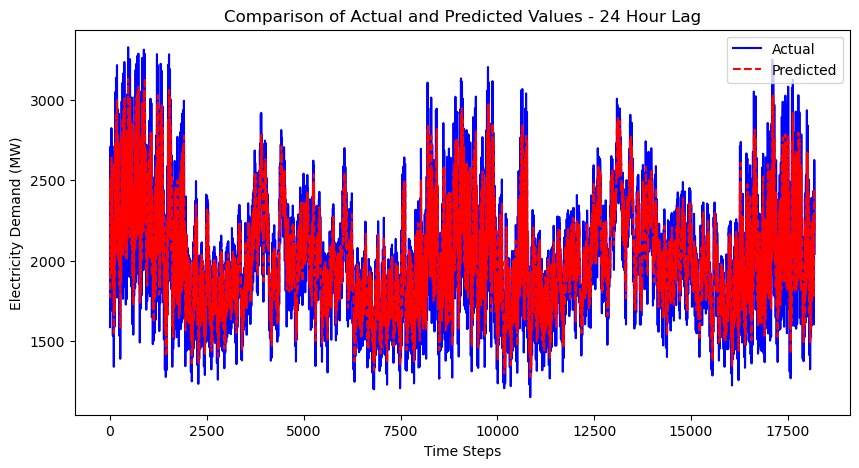

```python
import numpy as np
from tensorflow.keras.models import Sequential
from tensorflow.keras.layers import LSTM, Dense
from sklearn.metrics import mean_squared_error
import matplotlib.pyplot as plt

# Define the LSTM model
def train_single_layer_lstm_24h(X_train, Y_train, X_test, Y_test, epochs=10, batch_size=64):
    model = Sequential([
        LSTM(50, input_shape=(X_train.shape[1], X_train.shape[2]), activation='relu'),  # 50 units, shape (24, 1)
        Dense(1)  # Output layer with one neuron
    ])
    model.compile(optimizer='adam', loss='mean_squared_error')

    # Train the model
    history = model.fit(X_train, Y_train, epochs=epochs, batch_size=batch_size,
                        validation_data=(X_test, Y_test), verbose=1)
    return model, history

# Function to evaluate the model and plot results
def evaluate_and_plot_model_24h(model, X_test, Y_test):
    Y_pred = model.predict(X_test)
    rmse = np.sqrt(mean_squared_error(Y_test, Y_pred.flatten()))
    print(f"RMSE: {rmse}")

    # Plotting actual vs predicted values
    plt.figure(figsize=(10, 5))
    plt.plot(Y_test, label='Actual', color='blue')
    plt.plot(Y_pred, label='Predicted', color='red', linestyle='--')
    plt.title('Comparison of Actual and Predicted Values - 24 Hour Lag')
    plt.xlabel('Time Steps')
    plt.ylabel('Electricity Demand (MW)')
    plt.legend()
    plt.show()
    return rmse


# Training the model
model_24h, history_24h = train_single_layer_lstm_24h(X_train_24h, Y_train_24h, X_test_24h, Y_test_24h)

# Evaluating and plotting the model performance
rmse_24h = evaluate_and_plot_model_24h(model_24h, X_test_24h, Y_test_24h)
```

# Fit a bidirectional LSTM with lag = 24 hours

```
1611/1611 ━━━━━━━━━━━━━━━━━━━━ 13s 6ms/step - loss: 320645.7812 - val_loss: 93347.0000
1611/1611 ━━━━━━━━━━━━━━━━━━━━ 11s 7ms/step - loss: 55303.6523 - val_loss: 13264.0029
1611/1611 ━━━━━━━━━━━━━━━━━━━━ 11s 7ms/step - loss: 14927.6885 - val_loss: 12792.2891
1611/1611 ━━━━━━━━━━━━━━━━━━━━ 12s 8ms/step - loss: 12818.1748 - val_loss: 10073.5664
1611/1611 ━━━━━━━━━━━━━━━━━━━━ 13s 8ms/step - loss: 8445.6855 - val_loss: 4889.4263
1611/1611 ━━━━━━━━━━━━━━━━━━━━ 13s 8ms/step - loss: 7501.1382 - val_loss: 6749.9873
1611/1611 ━━━━━━━━━━━━━━━━━━━━ 15s 9ms/step - loss: 7236.2681 - val_loss: 4204.8496
1611/1611 ━━━━━━━━━━━━━━━━━━━━ 15s 9ms/step - loss: 4748.8853 - val_loss: 4102.6001
1611/1611 ━━━━━━━━━━━━━━━━━━━━ 18s 11ms/step - loss: 4771.4160 - val_loss: 2923.4844
1611/1611 ━━━━━━━━━━━━━━━━━━━━ 17s 10ms/step - loss: 3944.2571 - val_loss: 3765.4514
569/569 ━━━━━━━━━━━━━━━━━━━━ 3s 4ms/step
RMSE: 61.36328684095545
```

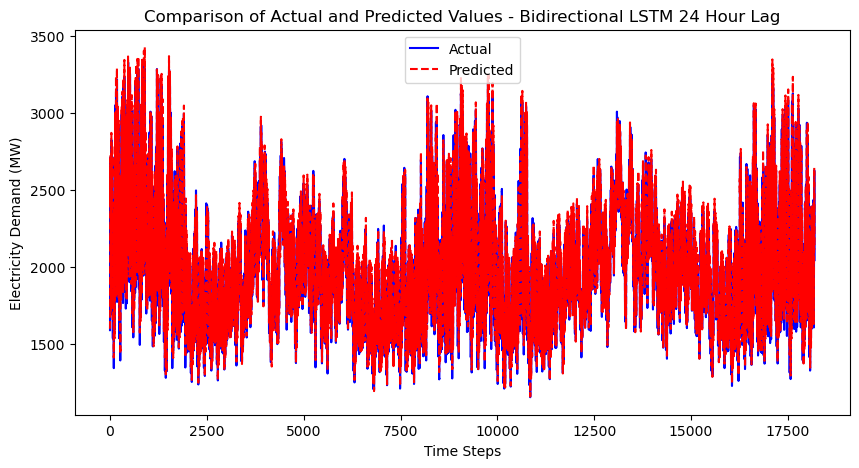

```python
import numpy as np
from tensorflow.keras.models import Sequential
from tensorflow.keras.layers import LSTM, Dense, Bidirectional
from sklearn.metrics import mean_squared_error
import matplotlib.pyplot as plt

# Define the bidirectional LSTM model
def train_bidirectional_lstm_24h(X_train, Y_train, X_test, Y_test, epochs=10, batch_size=64):
    model = Sequential([
        Bidirectional(LSTM(50, activation='relu'), input_shape=(X_train.shape[1], X_train.shape[2])),  # 50 units in each direction
        Dense(1)  # Output layer with one neuron
    ])
    model.compile(optimizer='adam', loss='mean_squared_error')

    # Train the model
    history = model.fit(X_train, Y_train, epochs=epochs, batch_size=batch_size,
                        validation_data=(X_test, Y_test), verbose=1)
    return model, history

# Function to evaluate the model and plot results
def evaluate_and_plot_bidirectional_model_24h(model, X_test, Y_test):
    Y_pred = model.predict(X_test)
    rmse = np.sqrt(mean_squared_error(Y_test, Y_pred.flatten()))
    print(f"RMSE: {rmse}")

    # Plotting actual vs predicted values
    plt.figure(figsize=(10, 5))
    plt.plot(Y_test, label='Actual', color='blue')
    plt.plot(Y_pred, label='Predicted', color='red', linestyle='--')
    plt.title('Comparison of Actual and Predicted Values - Bidirectional LSTM 24 Hour Lag')
    plt.xlabel('Time Steps')
    plt.ylabel('Electricity Demand (MW)')
    plt.legend()
    plt.show()
    return rmse


# Training the bidirectional model
model_bi_24h, history_bi_24h = train_bidirectional_lstm_24h(X_train_24h, Y_train_24h, X_test_24h, Y_test_24h)

# Evaluating and plotting the model performance
rmse_bi_24h = evaluate_and_plot_bidirectional_model_24h(model_bi_24h, X_test_24h, Y_test_24h)
```

# Plot results on test set and compare performance using RMSE

RMSE

Fit a single layer LSTM with lag = 3 hours: 46

Fit a single layer LSTM with lag = 24 hours: 136

Fit a bidirectional LSTM with lag = 24 hours: 61

Fitting a bidirectional LSTM model with a lag of 24 hours involves modifying the LSTM structure to use a Bidirectional wrapper, which processes the input data in both forward and reverse directions. This dual-direction processing can **capture patterns that may be missed when data is processed in just one direction, often leading to improved performance on sequences where context from both past and future is beneficial**.

The superior performance of the 3-hour lag model suggests that for this particular dataset, the **most relevant information for predicting future values lies in the immediate few hours rather than the full day**. This can often be the case in datasets where short-term fluctuations are more predictive of immediate future values than the broader trends captured by longer lags.